# EEG Data Analysis Report

Ruilong Chen

2025-05-01

## Introduction

### Data Discription

The dataset consists of EEG recordings from 10 college students as they watched MOOC video clips of varying difficulty, with corresponding self-reported confusion ratings. The EEG signals were captured using a single-channel wireless MindSet over the frontal lobe, sampled every 0.5 seconds during the middle one-minute segment of each video. Each student watched 20 videos (10 easy, 10 difficult), and confusion labels were provided both as a 7-point scale and a binary classification. Given the potential of EEG signals—particularly Theta wave activity—to indicate cognitive states, this dataset presents an opportunity for feature selection, classification modeling, and causal inference.

### Objective

My vision for an R Markdown report includes an exploratory data analysis (EDA) of EEG signals, an overview of the variables, and an in-depth analysis of some variables. The report will generate tables and visualizations.

## Summary Statistics

[figure not shown]

This image presents a comparative analysis of various characteristics, including SubjectID, VideoID, Attention, Mediation, and brainwave frequency bands (e.g., Delta, Theta, Alpha, Beta, Gamma). The values are presented as medians with interquartile ranges, and p-values are provided to indicate statistical significance. Key findings include significant differences in VideoID, Beta1, Beta2, and Gamma2, while other metrics like Attention and Alpha2 show no significant differences.

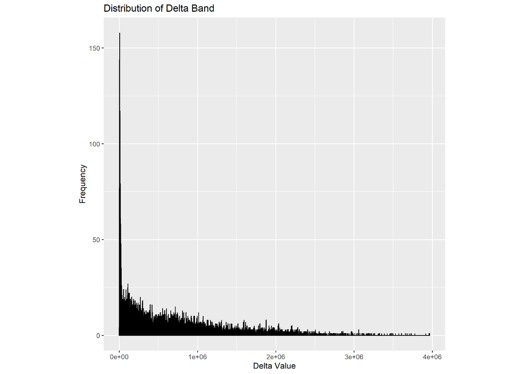

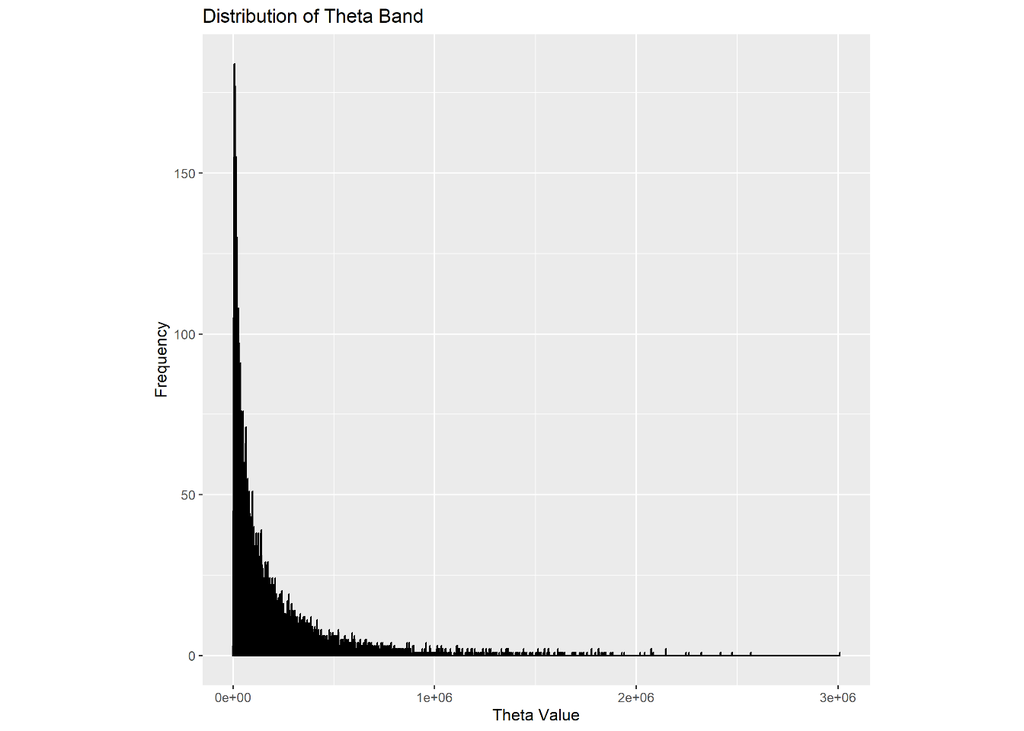

Both graphs illustrate the distribution characteristics of brainwave frequency bands. The Delta Band and Theta Band show higher frequencies at lower values, but the Delta Band has a broader distribution with a longer tail.